# Analysis of white wine

#### by

Sebastian P Joseph

========================================================

# Short description

This tidy data set contains 4,898 white wines with 11 variables on quantifying the chemical properties of each wine. At least 3 wine experts rated the quality of each wine, providing a rating between 0 (very bad) and 10 (very excellent).

# Summary of the data

```
##   X fixed.acidity volatile.acidity citric.acid residual.sugar chlorides
## 1 1           7.0             0.27        0.36           20.7     0.045
## 2 2           6.3             0.30        0.34            1.6     0.049
## 3 3           8.1             0.28        0.40            6.9     0.050
## 4 4           7.2             0.23        0.32            8.5     0.058
## 5 5           7.2             0.23        0.32            8.5     0.058
## 6 6           8.1             0.28        0.40            6.9     0.050
##   free.sulfur.dioxide total.sulfur.dioxide density   pH sulphates alcohol
## 1                  45                  170  1.0010 3.00      0.45     8.8
## 2                  14                  132  0.9940 3.30      0.49     9.5
## 3                  30                   97  0.9951 3.26      0.44    10.1
## 4                  47                  186  0.9956 3.19      0.40     9.9
## 5                  47                  186  0.9956 3.19      0.40     9.9
## 6                  30                   97  0.9951 3.26      0.44    10.1
##   quality
## 1       6
## 2       6
## 3       6
## 4       6
## 5       6
## 6       6
```

# Description of the dataset

1 Fixed acidity: most acids involved with wine or fixed or nonvolatile (do not evaporate readily).

2 Volatile acidity: The amount of acetic acid in wine, which at too high of levels can lead to an unpleasant, vinegar taste.

3 Citric acid: found in small quantities, citric acid can add ‘freshness’ and flavor to wines.

4 Residual sugar: the amount of sugar remaining after fermentation stops, it’s rare to find wines with less than 1 gram/liter and wines with greater than 45 grams/liter are considered sweet.

5 Chlorides: the amount of salt in the wine.

6 Free sulfur dioxide: the free form of SO2 exists in equilibrium between molecular SO2 (as a dissolved gas) and bisulfite ion; it prevents microbial growth and the oxidation of wine.

7 Total sulfur dioxide: amount of free and bound forms of S02; in low concentrations, SO2 is mostly undetectable in wine, but at free SO2 concentrations over 50 ppm, SO2 becomes evident in the nose and taste of wine.

8 Density: the density of water is close to that of water depending on the percent alcohol and sugar content.

9 pH: describes how acidic or basic a wine is on a scale from 0 (very acidic) to 14 (very basic); most wines are between 3-4 on the pH scale.

10 Sulphates: a wine additive which can contribute to sulfur dioxide gas (S02) levels, wich acts as an antimicrobial and antioxidant.

11 Alcohol: the percent alcohol content of the wine

```
Output variable (based on sensory data):
```

12 Quality (score between 0 and 10).

# Process of data munging

The variable ‘X’ is supposed to be removed because it just does the numbering of wines in the given dataset

```
##   fixed.acidity volatile.acidity citric.acid residual.sugar chlorides
## 1           7.0             0.27        0.36           20.7     0.045
## 2           6.3             0.30        0.34            1.6     0.049
## 3           8.1             0.28        0.40            6.9     0.050
## 4           7.2             0.23        0.32            8.5     0.058
## 5           7.2             0.23        0.32            8.5     0.058
## 6           8.1             0.28        0.40            6.9     0.050
##   free.sulfur.dioxide total.sulfur.dioxide density   pH sulphates alcohol
## 1                  45                  170  1.0010 3.00      0.45     8.8
## 2                  14                  132  0.9940 3.30      0.49     9.5
## 3                  30                   97  0.9951 3.26      0.44    10.1
## 4                  47                  186  0.9956 3.19      0.40     9.9
## 5                  47                  186  0.9956 3.19      0.40     9.9
## 6                  30                   97  0.9951 3.26      0.44    10.1
##   quality
## 1       6
## 2       6
## 3       6
## 4       6
## 5       6
## 6       6
```

# Quality coloumn can be divided into 3

```
##   fixed.acidity volatile.acidity citric.acid residual.sugar chlorides
## 1           7.0             0.27        0.36           20.7     0.045
## 2           6.3             0.30        0.34            1.6     0.049
## 3           8.1             0.28        0.40            6.9     0.050
## 4           7.2             0.23        0.32            8.5     0.058
## 5           7.2             0.23        0.32            8.5     0.058
## 6           8.1             0.28        0.40            6.9     0.050
##   free.sulfur.dioxide total.sulfur.dioxide density   pH sulphates alcohol
## 1                  45                  170  1.0010 3.00      0.45     8.8
## 2                  14                  132  0.9940 3.30      0.49     9.5
## 3                  30                   97  0.9951 3.26      0.44    10.1
## 4                  47                  186  0.9956 3.19      0.40     9.9
## 5                  47                  186  0.9956 3.19      0.40     9.9
## 6                  30                   97  0.9951 3.26      0.44    10.1
##   quality quality.type citric.type
## 1       6       better         low
## 2       6       better         low
## 3       6       better         low
## 4       6       better         low
## 5       6       better         low
## 6       6       better         low
```

# Summary of the data

```
##  fixed.acidity    volatile.acidity  citric.acid     residual.sugar
##  Min.   : 3.800   Min.   :0.0800   Min.   :0.0000   Min.   : 0.600
##  1st Qu.: 6.300   1st Qu.:0.2100   1st Qu.:0.2700   1st Qu.: 1.700
##  Median : 6.800   Median :0.2600   Median :0.3200   Median : 5.200
##  Mean   : 6.855   Mean   :0.2782   Mean   :0.3342   Mean   : 6.391
##  3rd Qu.: 7.300   3rd Qu.:0.3200   3rd Qu.:0.3900   3rd Qu.: 9.900
##  Max.   :14.200   Max.   :1.1000   Max.   :1.6600   Max.   :65.800
##
##    chlorides       free.sulfur.dioxide total.sulfur.dioxide
##  Min.   :0.00900   Min.   :  2.00      Min.   :  9.0
##  1st Qu.:0.03600   1st Qu.: 23.00      1st Qu.:108.0
##  Median :0.04300   Median : 34.00      Median :134.0
##  Mean   :0.04577   Mean   : 35.31      Mean   :138.4
##  3rd Qu.:0.05000   3rd Qu.: 46.00      3rd Qu.:167.0
##  Max.   :0.34600   Max.   :289.00      Max.   :440.0
##
##     density             pH          sulphates         alcohol
##  Min.   :0.9871   Min.   :2.720   Min.   :0.2200   Min.   : 8.00
##  1st Qu.:0.9917   1st Qu.:3.090   1st Qu.:0.4100   1st Qu.: 9.50
##  Median :0.9937   Median :3.180   Median :0.4700   Median :10.40
##  Mean   :0.9940   Mean   :3.188   Mean   :0.4898   Mean   :10.51
##  3rd Qu.:0.9961   3rd Qu.:3.280   3rd Qu.:0.5500   3rd Qu.:11.40
##  Max.   :1.0390   Max.   :3.820   Max.   :1.0800   Max.   :14.20
##
##     quality      quality.type  citric.type   quality.factor
##  Min.   :3.000   normal:  20   low   :4584   3:  20
##  1st Qu.:5.000   better:3818   medium: 312   4: 163
##  Median :6.000   good  :1060   high  :   2   5:1457
##  Mean   :5.878                               6:2198
##  3rd Qu.:6.000                               7: 880
##  Max.   :9.000                               8: 175
##                                              9:   5
```

# Univariate plot section

Histogram of fixed acidity

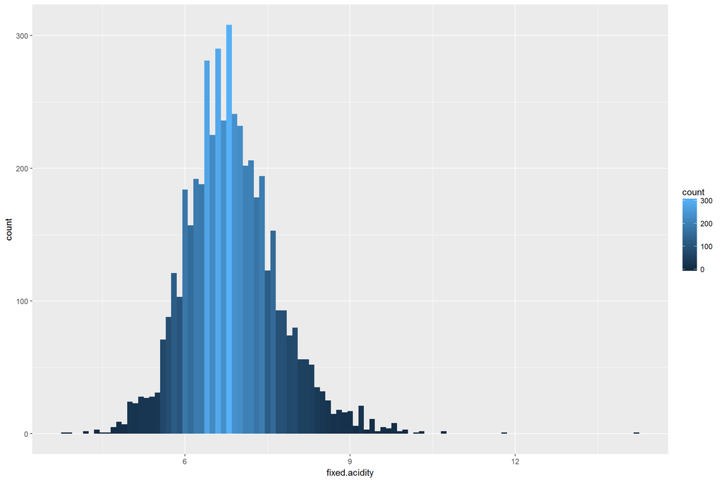

The fixed acidity as shown in the above plot depicts a normal distribution curve.I found that the mean is approximately 6.8 and the median is around 6.8 The maximum count is nearly 310 in an interval range of {3.80, 14.2}

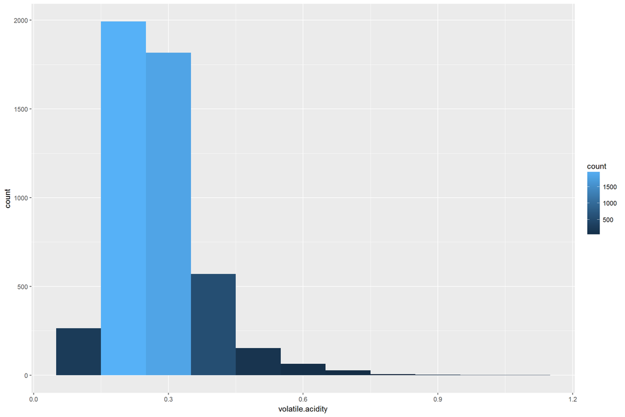

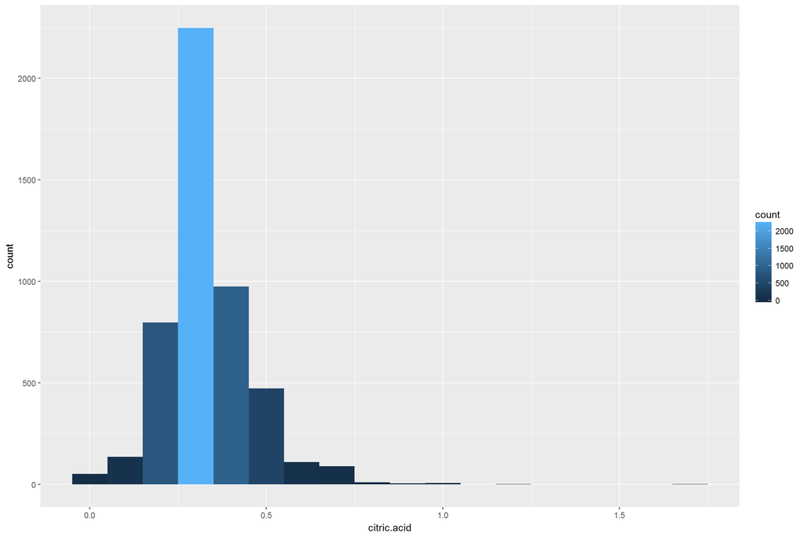

The citric acid as shown in the above plot depicts a normal distribution curve.I found that the mean is approximately 0.33 and the median is around 0.32 in an interval range of {0, 1.66}.

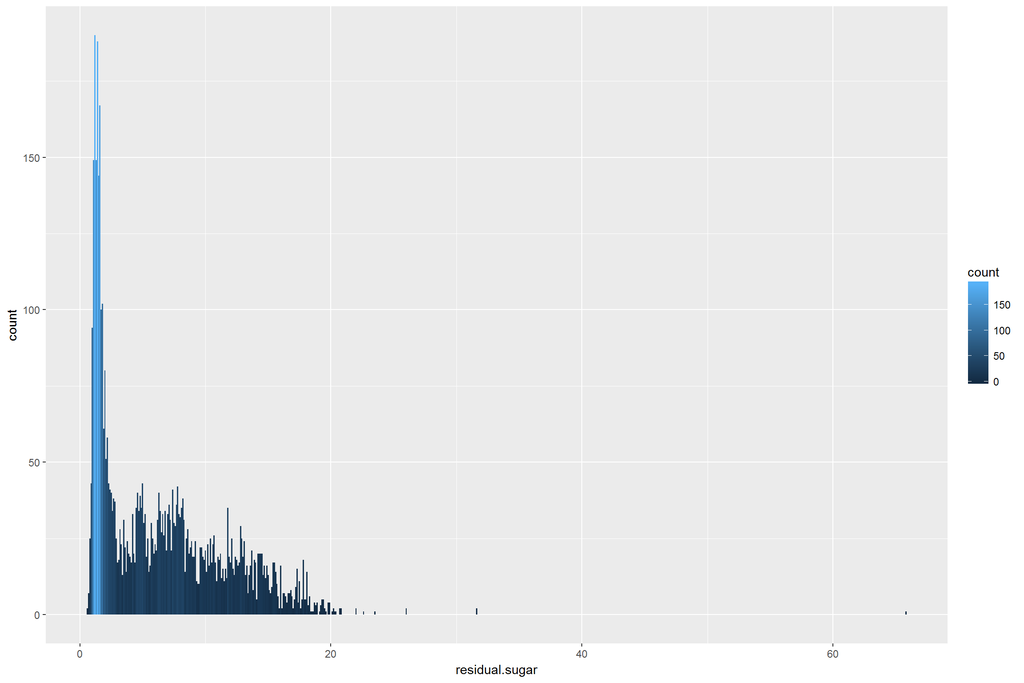

The residual sugar as shown in the above plot depicts a positive skew distribution curve.I found that the mean is approximately 6.39 and the median is around 5.2 in an interval range of {0.60, 65.8}

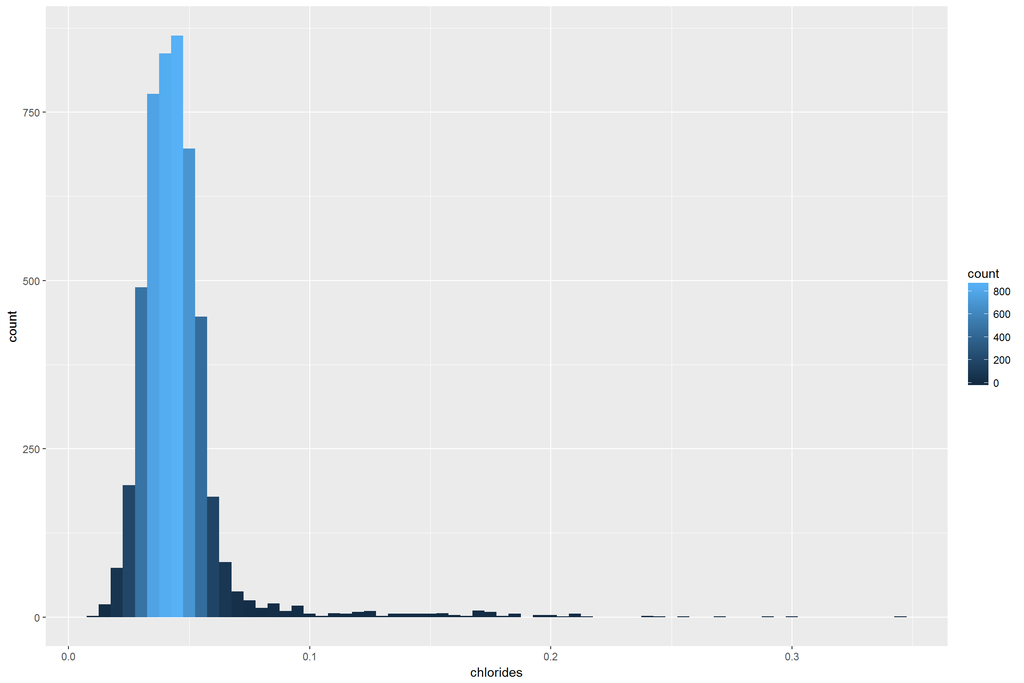

The chlorides as shown in the above plot depicts a positive skew distribution curve.I found that the mean is approximately 0.045 and the median is around 0.043 in an interval range of {0.009, 0.346}

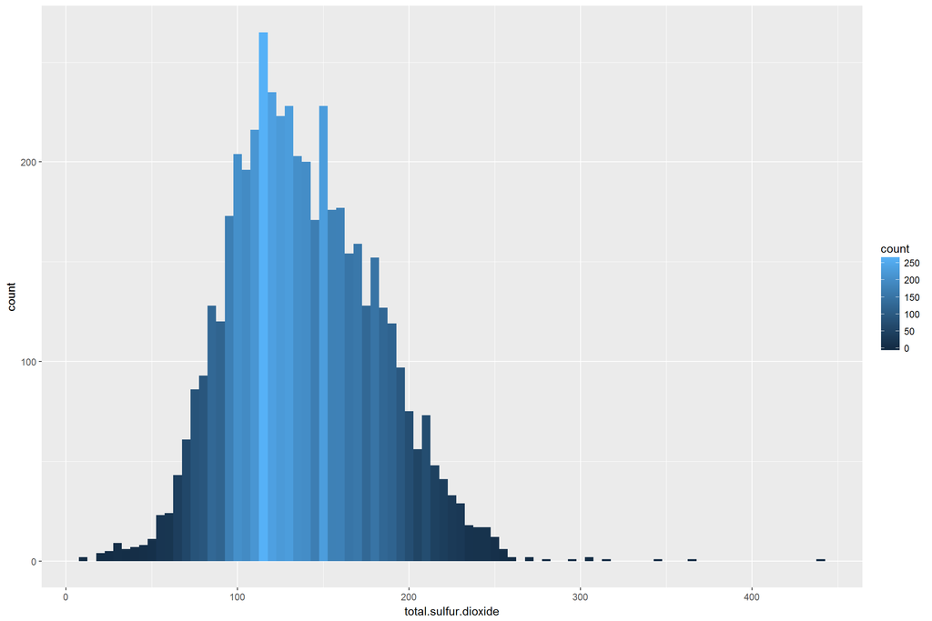

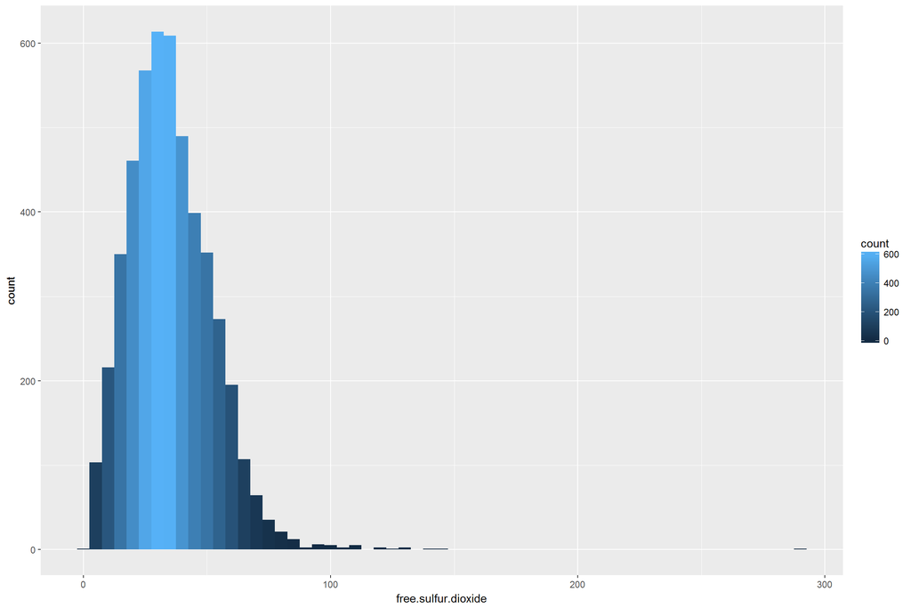

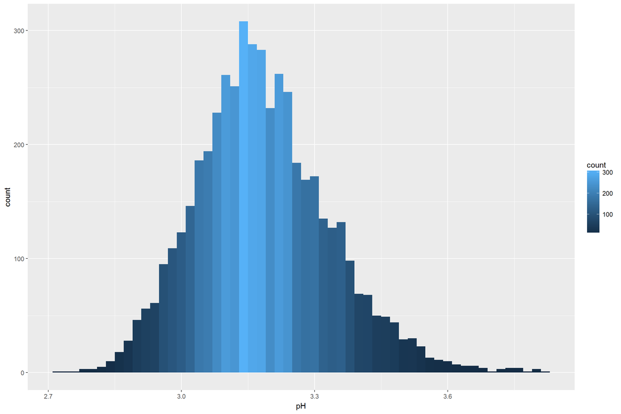

The pH as shown in the above plot depicts a binomial distribution curve.I found that the mean is approximately 3.188 and the median is around 3.18 in an interval range of {2.72, 3.82}

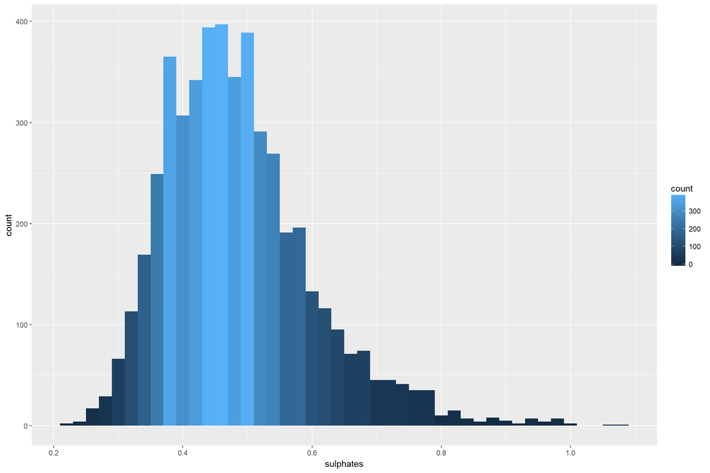

The sulphates as shown in the above plot depicts a binomial distribution curve.I found that the mean is approximately 0.489 and the median is around 0.47 in an interval range of {0.22, 1.08}

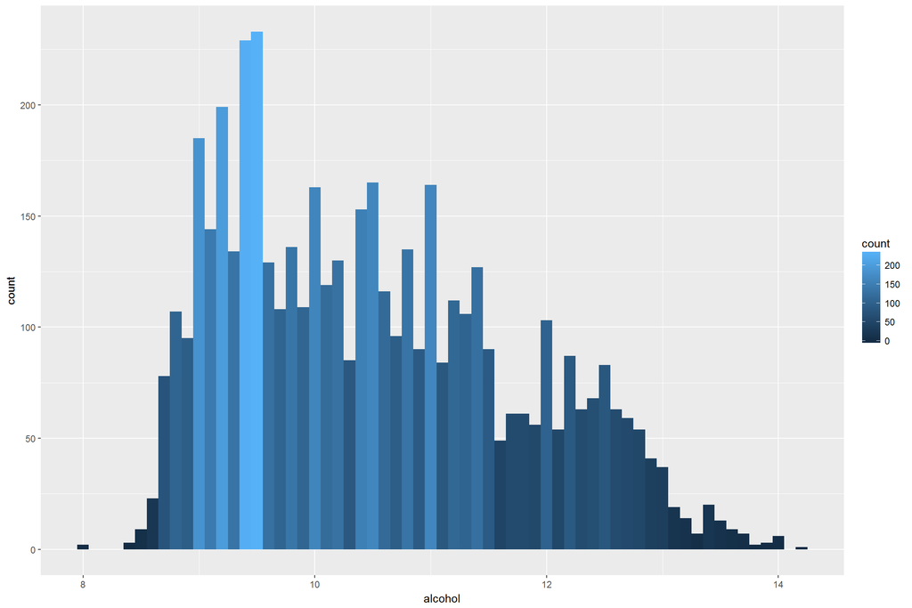

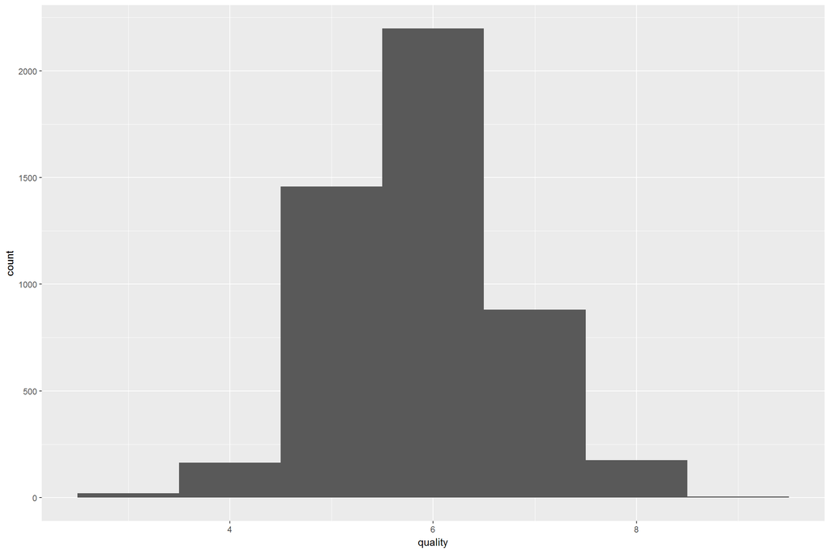

# Plotting new variables

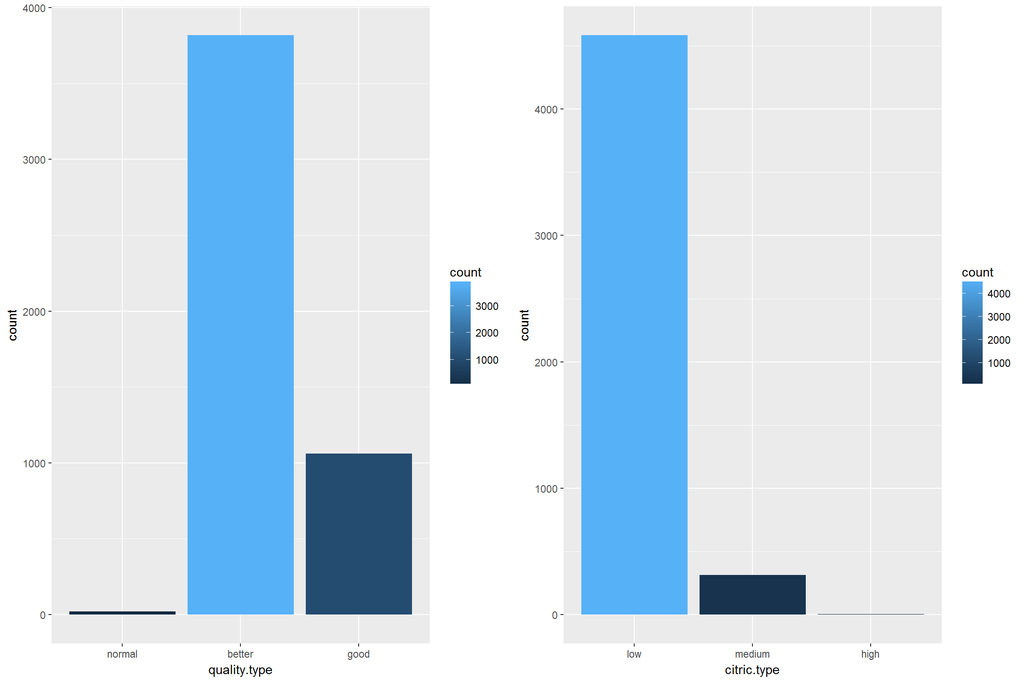

White wine has a better quality wine. normal quality.type has a count of 20, better quality.type of 3818 and good quality.type of 1060. totally three categories. White wine produces better quality wine with low citrus level.White wine consists of less amount of flavour in wine. less citric.type has a count of 4584, medium citric.type of 312 and more citric.type of 2.Totally three categories.

# Transforming the variables

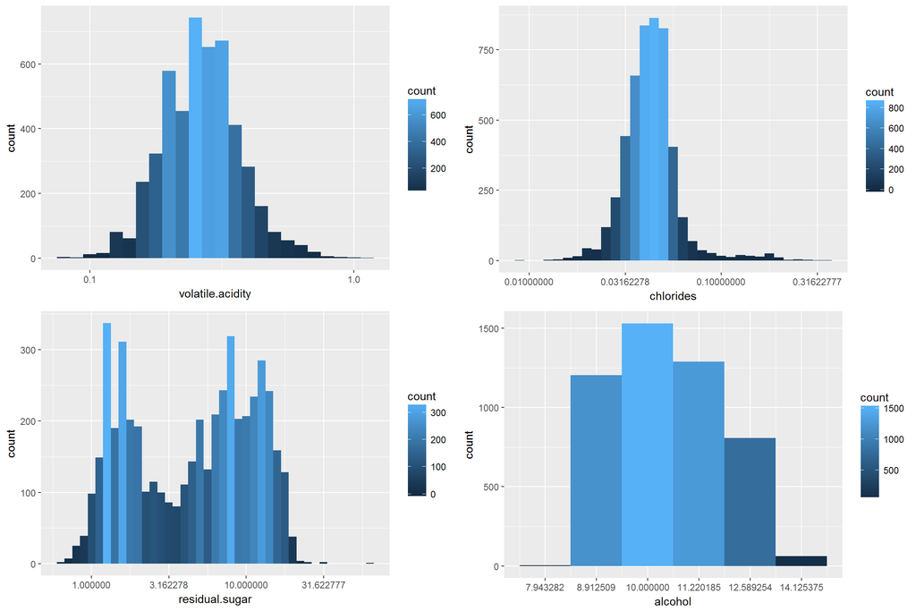

The breaks function is used in order to provide sufficient view in the plots with the log values.The Volatile acidity plot as we can see depicts a binomial distribution The Chlorides as we can see got a binomial distribution The Residual sugar as we can see depicts a bimodal distribution and Alcohol got binomial distribution

# Coorelation between the variables

Quality of alcohol

```
##
##  Pearson's product-moment correlation
##
## data:  white$quality and white$alcohol
## t = 33.858, df = 4896, p-value < 2.2e-16
## alternative hypothesis: true correlation is not equal to 0
## 95 percent confidence interval:
##  0.4126015 0.4579941
## sample estimates:
##       cor
## 0.4355747
```

–>The correlation between quality and alcohol is 0.4355747.

Density of alcohol

```
##
##  Pearson's product-moment correlation
##
## data:  white$density and white$alcohol
## t = -87.255, df = 4896, p-value < 2.2e-16
## alternative hypothesis: true correlation is not equal to 0
## 95 percent confidence interval:
##  -0.7908646 -0.7689315
## sample estimates:
##        cor
## -0.7801376
```

–>The correlation between density and alcohol is -0.7801376

Density of chlorides

```
##
##  Pearson's product-moment correlation
##
## data:  white$density and white$chlorides
## t = 18.624, df = 4896, p-value < 2.2e-16
## alternative hypothesis: true correlation is not equal to 0
## 95 percent confidence interval:
##  0.2308679 0.2831779
## sample estimates:
##       cor
## 0.2572113
```

–>The correlation between density and chloride is 0.2572113

Density of sulphates

```
##
##  Pearson's product-moment correlation
##
## data:  white$density and white$sulphates
## t = 5.2269, df = 4896, p-value = 1.795e-07
## alternative hypothesis: true correlation is not equal to 0
## 95 percent confidence interval:
##  0.04658388 0.10228621
## sample estimates:
##        cor
## 0.07449315
```

–>The correlation between density and sulphate is 0.07449315

# Bivariate Plots Section

Chlorides and quality

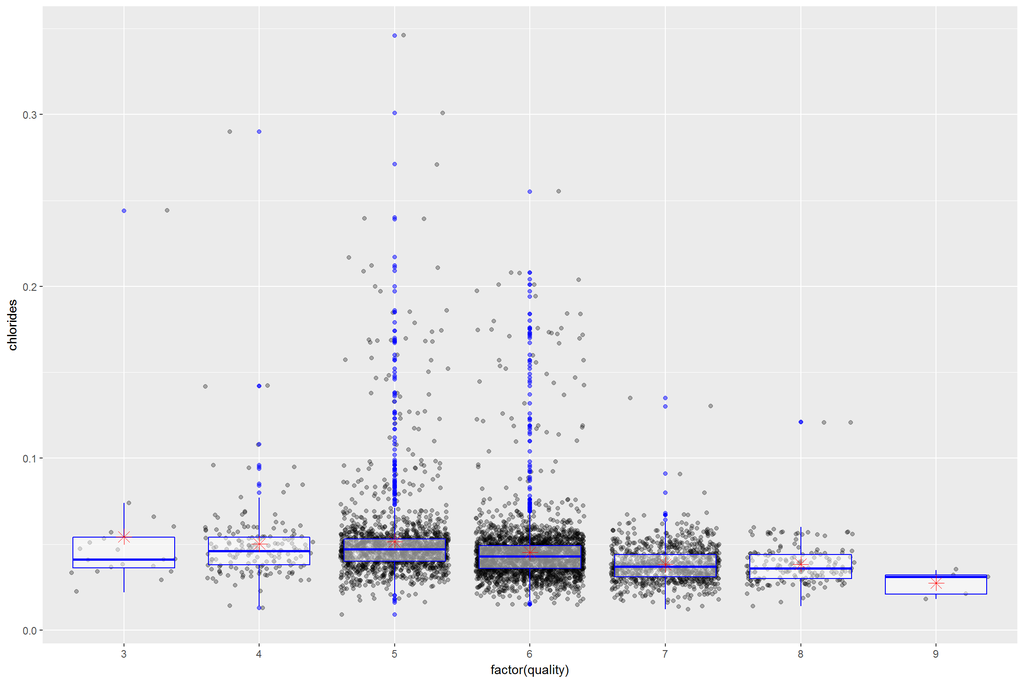

Many outliers at 5 and 6

Alcohol based on quality

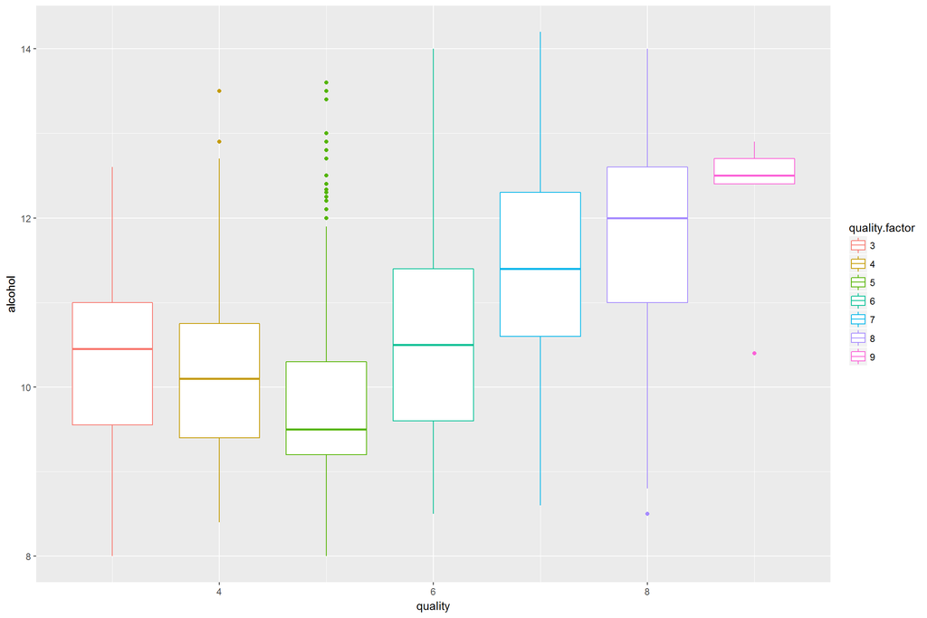

High quality wine has more amount of alcohol content in it!Most of the white wine samples seem to be of quality 5 and 6.Very high quality wine 9 seem to be less in number.

Free sulfurdioxide and total sulfurdioxide

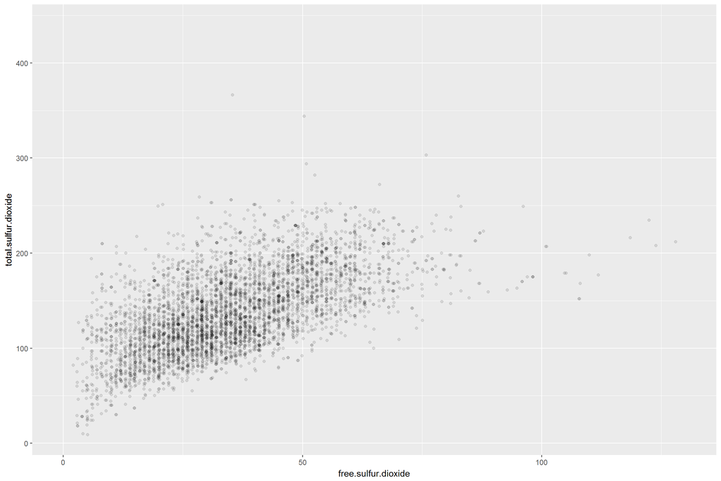

Volatile.acidity and citric.acid

```
##
##  Pearson's product-moment correlation
##
## data:  white$volatile.acidity and white$citric.acid
## t = -10.578, df = 4896, p-value < 2.2e-16
## alternative hypothesis: true correlation is not equal to 0
## 95 percent confidence interval:
##  -0.1767384 -0.1219760
## sample estimates:
##        cor
## -0.1494718
```

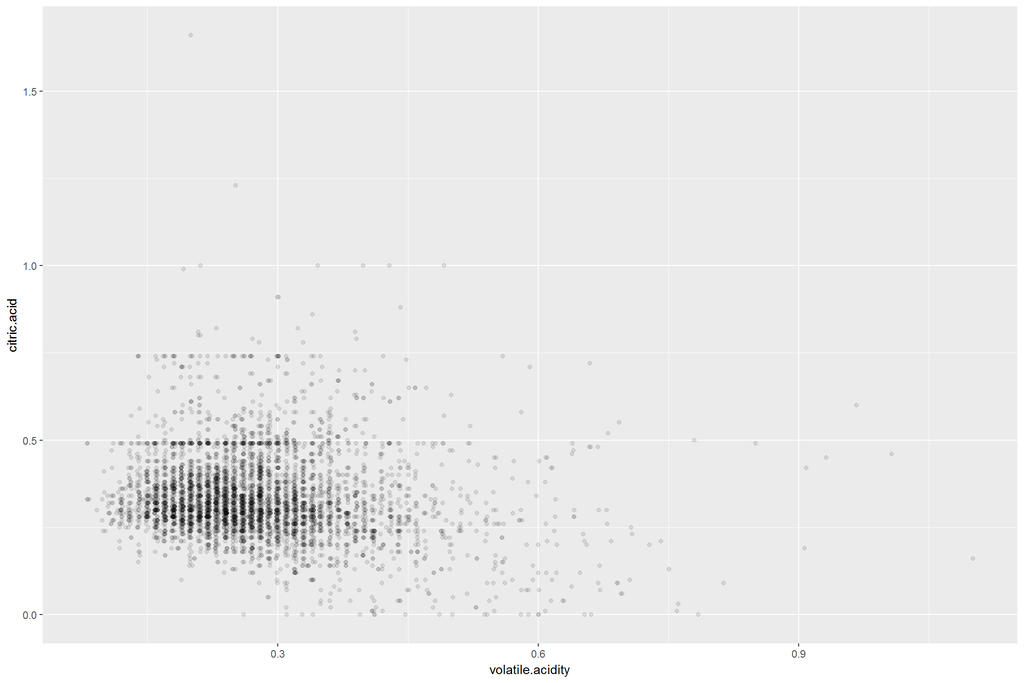

By comparing volatile.acidity and citric.acid plot, we observe that it has a negative correlation between them. The data lies mostly between the 2nd and 3rd quartile. volatile.acidity depends on the taste of the wine where less amount of volatile gives the better taste and citric.acid depends on the addition of flavour and freshness to wine where higher the amount of citric acid increases the freshness and flavour to the wine.

# Multivariate Plots Section

Alcohol and sulphates based on quality

```
##
##  Pearson's product-moment correlation
##
## data:  white$alcohol and white$sulphates
## t = -1.22, df = 4896, p-value = 0.2225
## alternative hypothesis: true correlation is not equal to 0
## 95 percent confidence interval:
##  -0.04541705  0.01057885
## sample estimates:
##         cor
## -0.01743277
```

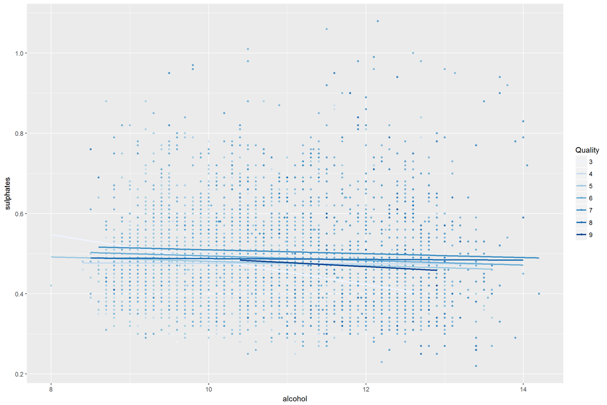

alcohol Density based on quality

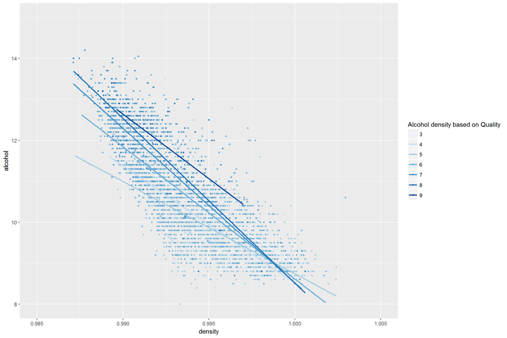

Density and pH based on quality

```
##
##  Pearson's product-moment correlation
##
## data:  white$density and white$pH
## t = -6.5776, df = 4896, p-value = 5.281e-11
## alternative hypothesis: true correlation is not equal to 0
## 95 percent confidence interval:
##  -0.1212801 -0.0657574
## sample estimates:
##         cor
## -0.09359149
```

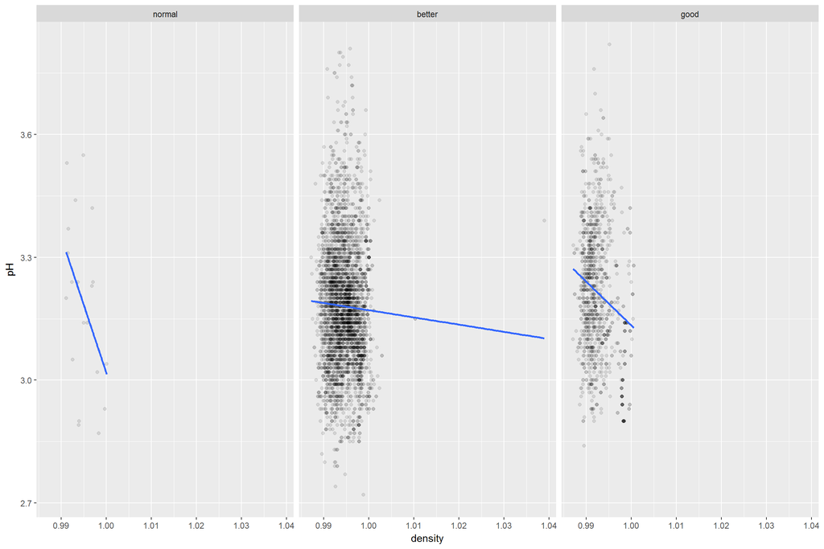

From this density and pH plot based on quality factor, we used facet for quality.type and also found negative correlation between density and pH. Then we used geom_smooth to add a summary line in the plot.

# Final Plots and Summary

### Alcohol based on quality

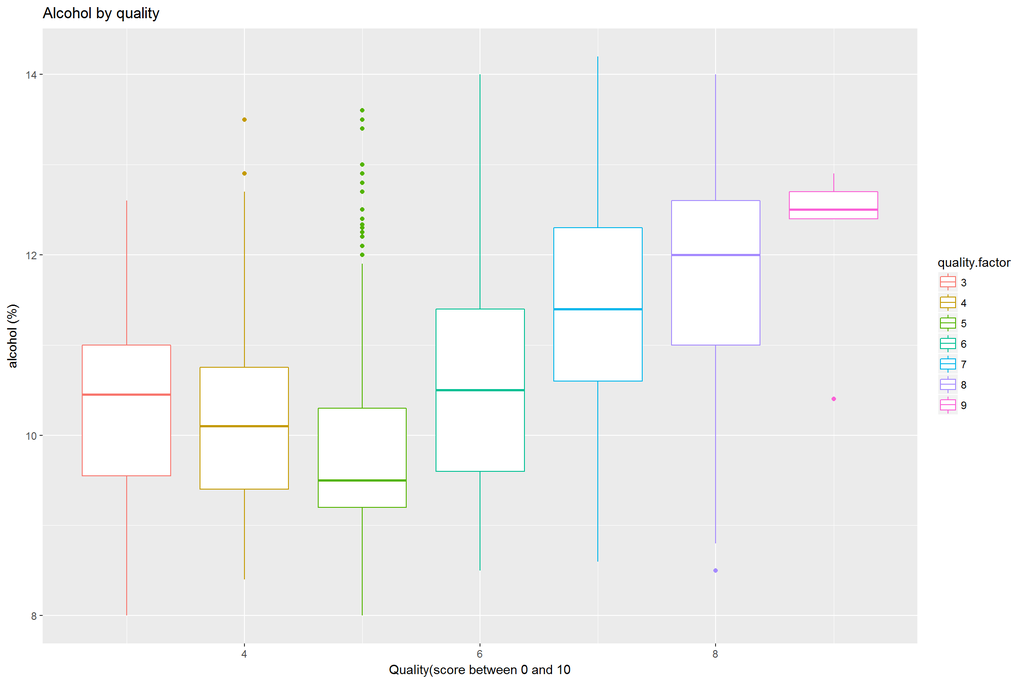

### Description One

High quality wine has more amount of alcohol content in it!Most of the white wine samples seem to be of quality 5 and 6.Very high quality wine 9 seem to be less in number. As seen in the above graph we compare the alcohol content in the wine based on quality. As we see there are many outliers in quality number 5 and the quality is better for 6 and 7 as we see in the graph

### Density of alcohol based on quality

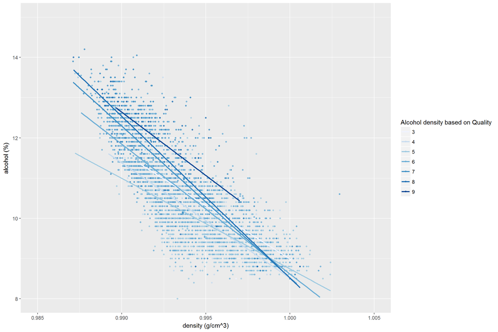

### Volatile.acidity vs citric.acid

```
##
##  Pearson's product-moment correlation
##
## data:  white$volatile.acidity and white$citric.acid
## t = -10.578, df = 4896, p-value < 2.2e-16
## alternative hypothesis: true correlation is not equal to 0
## 95 percent confidence interval:
##  -0.1767384 -0.1219760
## sample estimates:
##        cor
## -0.1494718
```

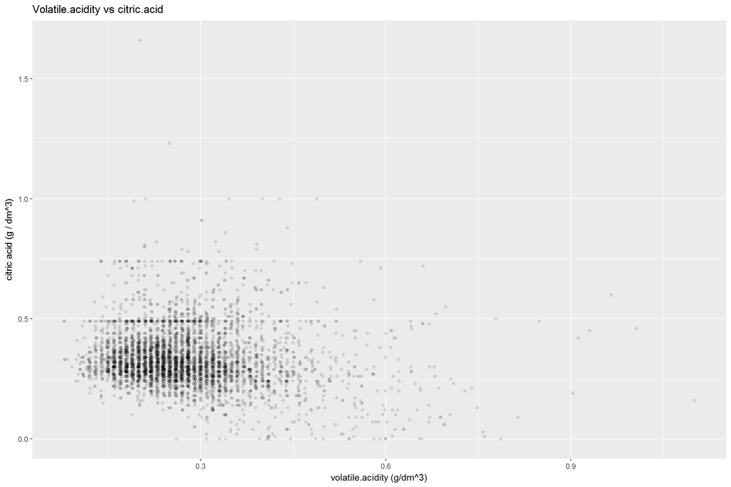

# Reflection